# Practical Machine Learning

Josip Jureta

26 septembre 2015

## Synopsis

The goal of this project (see this [link](https://class.coursera.org/predmachlearn-032/human_grading/view/courses/975201/assessments/4/submissions)) is to predict the manner in which different subjects performs barbell lifts. Data used in this project can be found on site of [Human Activity Recognition](http://groupware.les.inf.puc-rio.br/har).

## Data cleaning and data preprocessing

Data used for this project are downloaded from [here](https://d396qusza40orc.cloudfront.net/predmachlearn/pml-training.csv). Some of variables are not important for the prediction model (like for ex. user name or time serie data) and thay are removed during the data load.

For model building I used 70% of data and 30% are used for model validation.

```r
inTrain = createDataPartition(plmdata$classe, p = 0.70, list=FALSE)

training = plmdata[ inTrain,]
testing = plmdata[-inTrain,]
```

Some of predictors doesn’t contains enough of data (too much NA values). Those predictors are identified and removed from the training and testing data set.

```r
## remove predictors with a lot of NA
na_count <- sapply(training, function(y) sum(length(which(is.na(y)))))

columns_with_many_na <- na_count > (nrow(training) * 0.90)

training <- training[, -which(columns_with_many_na), with = FALSE]
testing <- testing[, -which(columns_with_many_na), with = FALSE]
plmTesting <- plmTesting[, -which(columns_with_many_na), with = FALSE]
```

Also, predictors with strong correlation between them are removed:

```r
## exclude correlated predictors
descrCor <-  cor(training[, -c('classe'), with = F])
highlyCorDescr <- findCorrelation(descrCor, cutoff = .75)

training <- training[, -highlyCorDescr, with = FALSE]
testing <- testing[, -highlyCorDescr, with = FALSE]
plmTesting <- plmTesting[, -highlyCorDescr, with = FALSE]
```

Verify if there are still data with near zero variability:

```r
nz <- data.table(nearZeroVar(training, saveMetrics=TRUE))
nzv <- nrow(nz[nzv == TRUE])
```

There is 0 rows with near zero variability.

The correlation between predictors I will continue to use for modeling is shown in this graph:

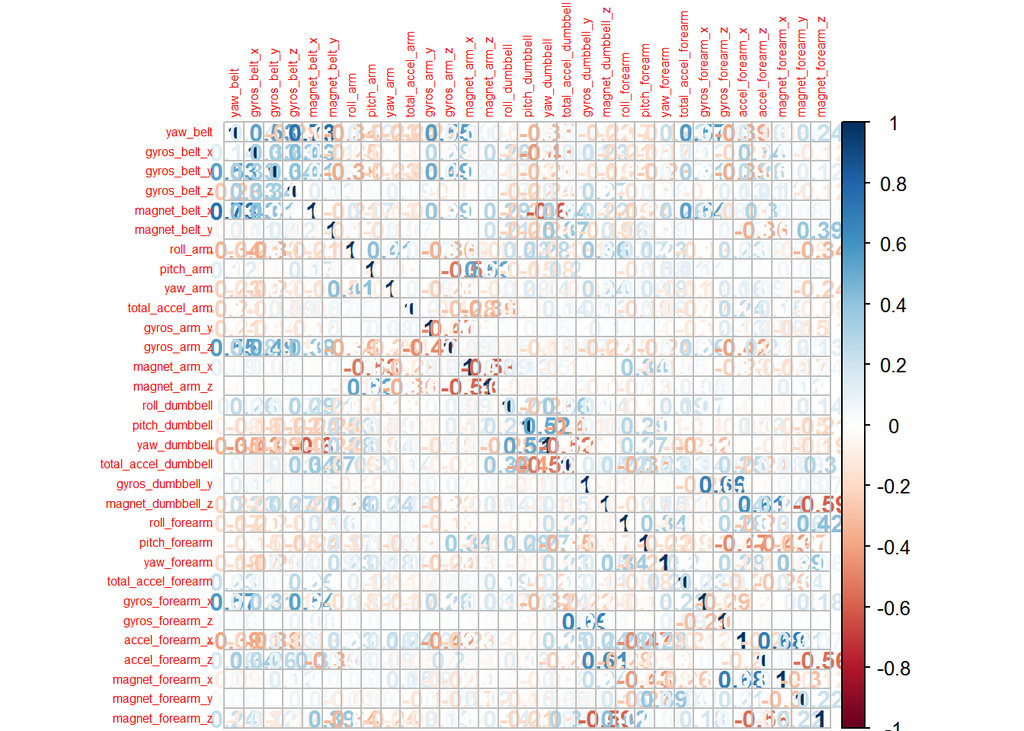

## Modeling

```r
preProc <- preProcess(training[, -c('classe'), with = F], method = "pca", thresh = 0.95)
pc <- predict(preProc, training[, -c('classe'), with = F])

# define training control
train_control <- trainControl(method="cv")
# train the model
model <- train(factor(classe) ~ .,
               data = training,
               trControl = train_control,
               preProcess = c("center", "scale", "pca"),
               importance = TRUE,
               allowParallel = TRUE,
               method = "rf")
# make predictions
predictions <- predict(model, testing)
# summarize results
cm <- confusionMatrix(predictions, factor(testing$classe))
```